# Assignment: Pupil dilation

Maarten van der Velde

# Setting up R session

```r
library(mgcv)
library(itsadug)
library(dplyr)
```

```r
library(ggplot2)
theme_set(theme_classic())

library(colorspace)
library(htmltools)

infoMessages("on")
packageVersion("mgcv")
```

```
## [1] '1.8.24'
```

```r
packageVersion("itsadug")
```

```
## [1] '2.3'
```

# Assignment

## Inspection of the data

```r
download.file("http://www.jacolienvanrij.com/Courses/LOT2018/Assignment/Data/pupilsize_S1.rds", "pupilsize_S1.rds", mode="wb")
dat <- readRDS('pupilsize_S1.rds')
```

```r
head(dat)
```

|  | Subject | Item | Event | Trial | Time | Xgaze | Ygaze | baseline | Pupil | Pupil_base | Pupil_norm | introOrder | imageType | StartS1 | NP1 | NP2 | EndS1 | Timebin |
| --- | --- | --- | --- | --- | --- | --- | --- | --- | --- | --- | --- | --- | --- | --- | --- | --- | --- | --- |
| 3418 | s01 | 16 | s01.16 | -31.5 | 3 | 515.1 | 389.8 | 1147.302 | 1197 | 49.69841 | 0.04331765 | A1 | other-oriented | 500 | 995 | 1875 | 2490 | 50 |
| 3419 | s01 | 16 | s01.16 | -31.5 | 23 | 516.1 | 390.0 | 1147.302 | 1195 | 47.69841 | 0.04157443 | A1 | other-oriented | 500 | 995 | 1875 | 2490 | 50 |
| 3420 | s01 | 16 | s01.16 | -31.5 | 43 | 515.0 | 392.9 | 1147.302 | 1188 | 40.69841 | 0.03547316 | A1 | other-oriented | 500 | 995 | 1875 | 2490 | 50 |
| 3421 | s01 | 16 | s01.16 | -31.5 | 63 | 515.9 | 392.5 | 1147.302 | 1185 | 37.69841 | 0.03285833 | A1 | other-oriented | 500 | 995 | 1875 | 2490 | 50 |
| 3422 | s01 | 16 | s01.16 | -31.5 | 83 | 516.7 | 392.9 | 1147.302 | 1187 | 39.69841 | 0.03460155 | A1 | other-oriented | 500 | 995 | 1875 | 2490 | 50 |
| 3423 | s01 | 16 | s01.16 | -31.5 | 103 | 516.7 | 393.6 | 1147.302 | 1184 | 36.69841 | 0.03198672 | A1 | other-oriented | 500 | 995 | 1875 | 2490 | 150 |

```r
str(dat)
```

```
## 'data.frame':    44093 obs. of  18 variables:
##  $ Subject   : Factor w/ 10 levels "s01","s02","s03",..: 1 1 1 1 1 1 1 1 1 1 ...
##  $ Item      : Factor w/ 32 levels "1","2","3","4",..: 16 16 16 16 16 16 16 16 16 16 ...
##  $ Event     : Factor w/ 309 levels "s01.1","s02.1",..: 145 145 145 145 145 145 145 145 145 145 ...
##  $ Trial     : num  -31.5 -31.5 -31.5 -31.5 -31.5 -31.5 -31.5 -31.5 -31.5 -31.5 ...
##  $ Time      : int  3 23 43 63 83 103 123 143 163 183 ...
##  $ Xgaze     : num  515 516 515 516 517 ...
##  $ Ygaze     : num  390 390 393 392 393 ...
##  $ baseline  : num  1147 1147 1147 1147 1147 ...
##  $ Pupil     : num  1197 1195 1188 1185 1187 ...
##  $ Pupil_base: num  49.7 47.7 40.7 37.7 39.7 ...
##  $ Pupil_norm: num  0.0433 0.0416 0.0355 0.0329 0.0346 ...
##  $ introOrder: chr  "A1" "A1" "A1" "A1" ...
##  $ imageType : chr  "other-oriented" "other-oriented" "other-oriented" "other-oriented" ...
##  $ StartS1   : int  500 500 500 500 500 500 500 500 500 500 ...
##  $ NP1       : int  995 995 995 995 995 995 995 995 995 995 ...
##  $ NP2       : int  1875 1875 1875 1875 1875 1875 1875 1875 1875 1875 ...
##  $ EndS1     : int  2490 2490 2490 2490 2490 2490 2490 2490 2490 2490 ...
##  $ Timebin   : num  50 50 50 50 50 150 150 150 150 150 ...
```

There are four conditions in total: `imageType` (either `self-oriented` or `other-oriented`) is crossed with `introOrder` (either `A1` or `A2`). The plot below shows the grand average pupil dilation over time for each of these four conditions. The first noun phrase is always heard at 995 ms after trial onset, while the second NP is presented somewhere between 1585 ms and 2030 ms.

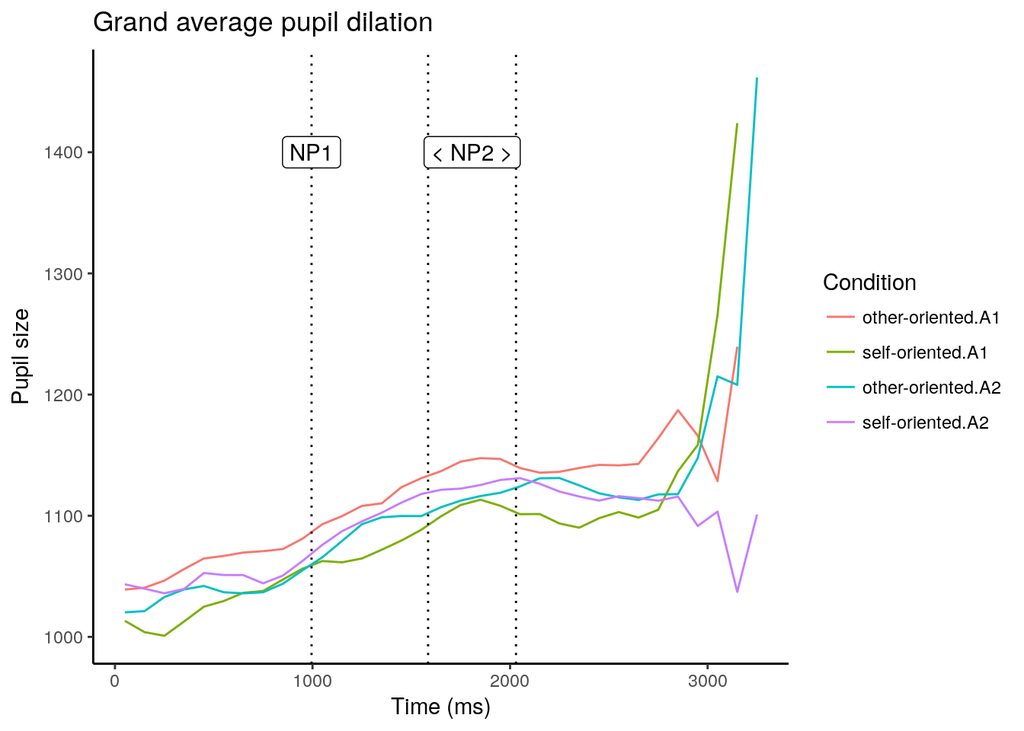

```r
# Group observations in 100ms bins based on timestamp, taking the center of each bin as the binned time value.
dat$Timebin <- timeBins(dat$Time, 100)

# Plot mean pupil size per time bin for each condition
dat %>%
  mutate(Condition = interaction(imageType, introOrder)) %>%
  group_by(Condition, Timebin) %>%
  summarise(pupil_mean = mean(Pupil, na.rm = TRUE)) %>%
  ggplot(aes(x = Timebin, y = pupil_mean, colour = Condition)) +
  geom_line() +
  geom_vline(xintercept = 995, linetype = "dotted") +
  annotate("label", x = 995, y = 1400, label = "NP1") +
  geom_vline(xintercept = 1585, linetype = "dotted") +
  geom_vline(xintercept = 2030, linetype = "dotted") +
  annotate("label", x = 1808, y = 1400, label = "< NP2 >") +
  labs(title = "Grand average pupil dilation", x = "Time (ms)", y = "Pupil size")
```

**What does the `Timebin` column represent? In case you want to see the code for calculating the timebins type `timeBins` in the command line. Why would it sometimes be useful to plot Timebin rather than raw timestamps?**

The `Timebin` column represents binned timestamps: all data points within a 100 ms range (e.g., from 0 ms to 100 ms) are assigned to a single bin and are given the central value of the bin (e.g., 50 ms). Using binned values rather than raw timestamps makes it possible to average over multiple trials in the same condition that are not measured at exactly the same time points. For example, in one trial the first measurement may be done at 2 ms, while in another trial it happens at 3 ms. Without binning, these values could not be averaged (so the plot would only show the average of a subset of trials that happen to align at each time point). With binning, however, both values are counted in the 50 ms bin, so the plot represents the data correctly (albeit slightly smoothed).

**Inspect the plot. Why would there be such a sudden increase in dilation after 3000 ms? Hint: type `tapply(dat$Time, list(dat$Event), max)` in the commandline.**

The final pupil measurement happens before 3000 ms in about three quarters of all trials, which strongly suggests that the stimulus may have only been shown for 3000 ms. This would mean that any data after 3000 ms should be disregarded. Since there are only a few observations in each condition after 3000 ms, the mean pupil size is all over the place.

## Baseline model

### a. Smooth

```r
nrow(dat)
```

```
## [1] 44093
```

There are about 44,000 observations, which means that `bam()` is the way to go.

```r
m1 <- bam(Pupil ~ s(Time), data = dat, method = "fREML", discrete = TRUE, nthreads = 8)
summary(m1)
```

```
##
## Family: gaussian
## Link function: identity
##
## Formula:
## Pupil ~ s(Time)
##
## Parametric coefficients:
##             Estimate Std. Error t value Pr(>|t|)
## (Intercept)   1095.8        2.2   498.1   <2e-16 ***
## ---
## Signif. codes:  0 '***' 0.001 '**' 0.01 '*' 0.05 '.' 0.1 ' ' 1
##
## Approximate significance of smooth terms:
##           edf Ref.df     F p-value
## s(Time) 5.009  6.106 58.95  <2e-16 ***
## ---
## Signif. codes:  0 '***' 0.001 '**' 0.01 '*' 0.05 '.' 0.1 ' ' 1
##
## R-sq.(adj) =  0.00808   Deviance explained = 0.819%
## fREML = 3.2806e+05  Scale est. = 1.6979e+05  n = 44093
```

**Inspect the summary. What does the intercept represent?**

The intercept represents the mean value of the dependent variable, Pupil, when the `Time` smooth is equal to zero. Note that this does not mean 'when `Time` is equal to zero', since the smooth is centered around zero (as the plot further down shows) and equals zero around 1300 ms.

**What does the summary of the smooth terms tell about the wiggliness of the smooth? (See the column `edf`)**

The smooth is definitely not a straight line (in which case the effective degrees of freedom would be close to 1), but a nonlinear curve that would need about 5 parameters to be represented parametrically (i.e., it is quite wiggly).

**What does it mean that the smooth term is significant?**

This smooth is significantly different from a straight horizontal line at y = 0 (discounting the intercept).

```
## Summary:
##  * Time : numeric predictor; with 30 values ranging from 0.000000 to 3243.000000.
```

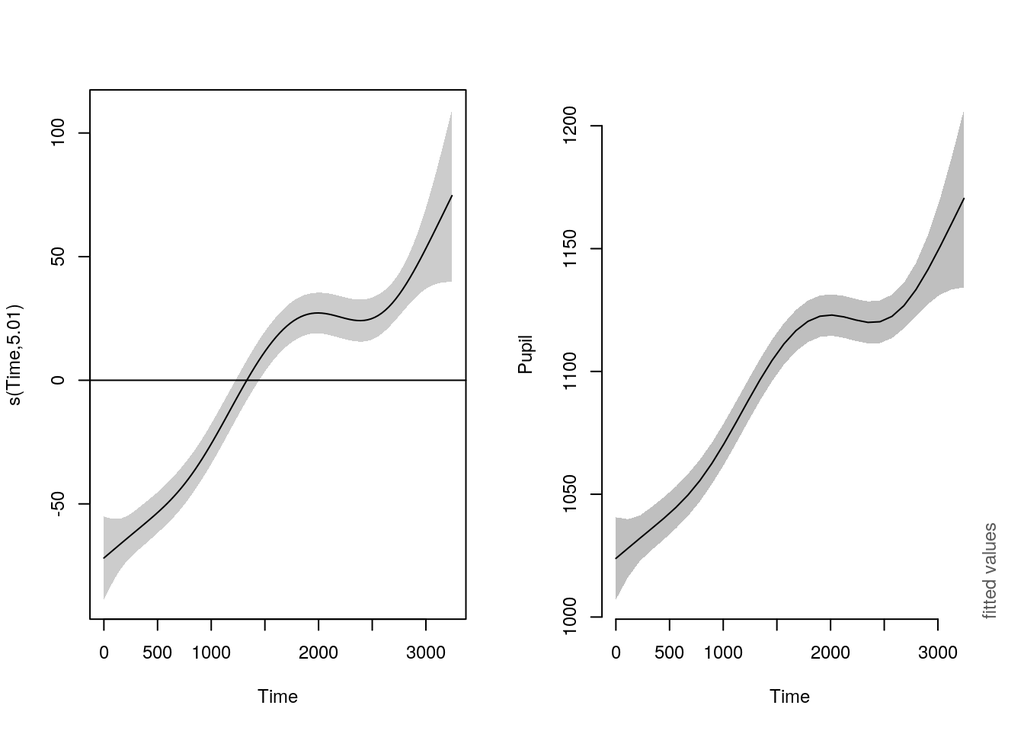

```r
par(mfrow=c(1,2), cex=0.75)

# Partial effect plot:
plot(m1, select=1, shade=TRUE)
abline(h=0)

# Fitted values:
plot_smooth(m1, view="Time")
```

**What is the difference between the two plots? What do the plots represent?**

The left plot shows only the partial effect of the fitted `Time` smooth, whereas the right plot adds the intercept to this smooth to get the fitted values.

### b. Random intercepts

Participants differ considerably in pupil dilation size, so the model should account for these differences:

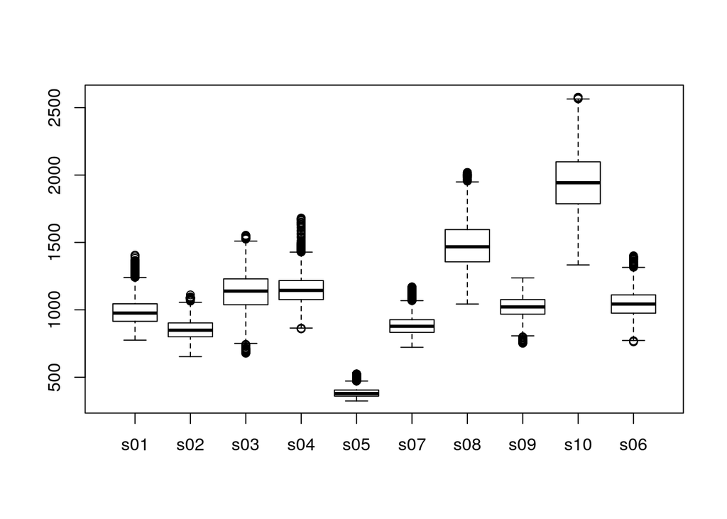

```r
boxplot(Pupil ~ Subject, data=dat)
```

Add a random intercept for subjects and items:

```r
m2 <- bam(Pupil ~ s(Time) + s(Subject, bs = "re") + s(Item, bs = "re"), data = dat, method = "fREML", discrete = TRUE, nthreads = 8)
summary(m2)
```

```
##
## Family: gaussian
## Link function: identity
##
## Formula:
## Pupil ~ s(Time) + s(Subject, bs = "re") + s(Item, bs = "re")
##
## Parametric coefficients:
##             Estimate Std. Error t value Pr(>|t|)
## (Intercept)   1092.3      128.7    8.49   <2e-16 ***
## ---
## Signif. codes:  0 '***' 0.001 '**' 0.01 '*' 0.05 '.' 0.1 ' ' 1
##
## Approximate significance of smooth terms:
##               edf Ref.df       F p-value
## s(Time)     7.156  8.167   497.8  <2e-16 ***
## s(Subject)  9.000  9.000 70936.7  <2e-16 ***
## s(Item)    30.842 31.000  5472.4  <2e-16 ***
## ---
## Signif. codes:  0 '***' 0.001 '**' 0.01 '*' 0.05 '.' 0.1 ' ' 1
##
## R-sq.(adj) =   0.92   Deviance explained =   92%
## fREML = 2.7273e+05  Scale est. = 13720     n = 44093
```

**What does the intercept represent?**

The intercept represents the mean pupil dilation when the `Time` smooth is equal to zero, averaged over subjects and items (which each have an additional offset represented by the random intercept).

**What does a random intercept term represent?**

A random intercept term represents the offset from the fixed intercept for each of its levels.

Visualise the smooth:

```r
par(mfrow=c(1,3), cex=0.75)

# Partial effect plot:
plot(m2, select=1, shade=TRUE)
abline(h=0)

# Fitted values:
plot_smooth(m2, view="Time")
```

```
## Summary:
##  * Time : numeric predictor; with 30 values ranging from 0.000000 to 3243.000000.
##  * Subject : factor; set to the value(s): s08.
##  * Item : factor; set to the value(s): 30.
```

```
## Summary:
##  * Time : numeric predictor; with 30 values ranging from 0.000000 to 3243.000000.
##  * Subject : factor; set to the value(s): s08. (Might be canceled as random effect, check below.)
##  * Item : factor; set to the value(s): 30. (Might be canceled as random effect, check below.)
##  * NOTE : The following random effects columns are canceled: s(Subject),s(Item)
##
```

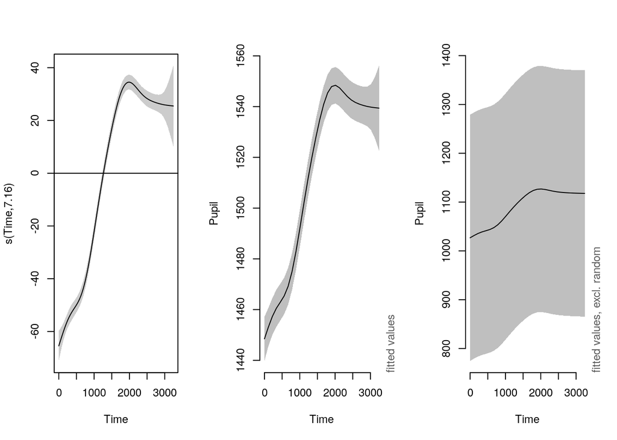

```r
# Fitted values without random effects:
plot_smooth(m2, view="Time", rm.ranef = TRUE)
```

**What do the plots represent?**

**Run the `plot_smooth` function again, but now add `rm.ranef = TRUE` as argument. Why did the plot change so much?**

The right plot excludes random effects, only showing the summed fixed effects for the theoretical 'average' subject/item. Since intercept differences between subjects and items are no longer accounted for, the model's estimate has much more uncertainty.

Inspect the random effects:

```r
par(mfrow=c(1,3), cex=0.75)

# Partial effect plot:
plot(m2, select=2)

#  get the values for individual subjects:
rand <- get_random(m2)
# note that get_random returns a list with
# the random adjustments for each random
# intercept or slope:
rand
```

```
## $`s(Subject)`
##        s01        s02        s03        s04        s05        s07
## -101.35580 -236.97467   39.30850   69.15512 -702.93190 -203.94798
##        s08        s09        s10        s06
##  386.88721  -55.72703  849.04661  -43.46006
##
## $`s(Item)`
##          1          2          3          4          5          6
## -22.382200 -45.002043  26.325577  17.032360  14.613574 -39.481439
##          7          8          9         10         11         12
## -30.402797 -23.352016  27.480195  26.426119  24.066491  82.178750
##         13         14         15         16         17         18
## -79.584052   7.161598  53.283967 110.271021 -43.767956 -51.974650
##         19         20         21         22         23         24
## -62.006637 -48.998285  13.032421  18.446475  76.034990 -17.815959
##         25         26         27         28         29         30
## -37.125036  16.776737  -6.530197 -28.831121  23.932690  34.730237
##         31         32
## -42.588331   8.049514
```

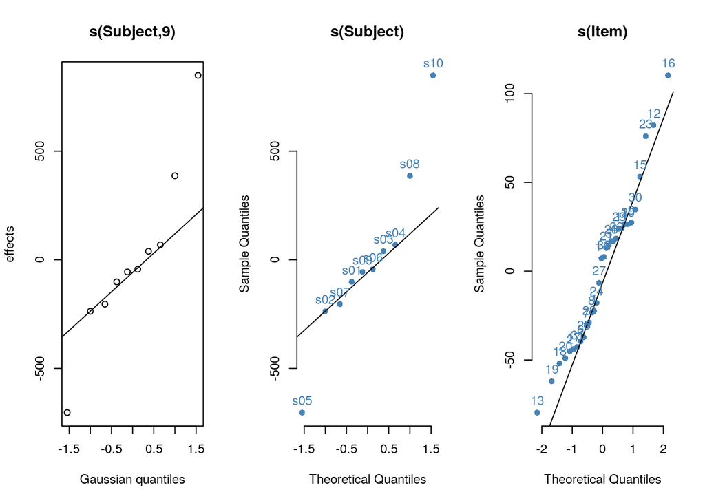

```r
# similar plot with subj names added:
xy <- qqnorm(rand[[1]], main='s(Subject)',
    col='steelblue', pch=16, bty='n') # <- some additional arguments that could be left out
qqline(rand[[1]])

text( xy$x, rand[[1]], labels=names( rand[[1]] ),
      pos=3, col="steelblue", xpd=TRUE) # <- some additional arguments that could be left out

# same for items:
xy <- qqnorm(rand[[2]], main='s(Item)',
    col='steelblue', pch=16, bty='n') # <- some additional arguments that could be left out
qqline(rand[[2]])

text( xy$x, rand[[2]], labels=names( rand[[2]] ),
      pos=3, col="steelblue", xpd=TRUE) # <- some additional arguments that could be left out
```

**What does this plot represent? What values are on the axes?**

These plots show the distribution of random intercepts for subjects (left and middle) and items (right). Each point represents the intercept offset for a particular subject/item. This offset is the value on the y-axis. For example, a y-value of 500 means that the intercept for the corresponding subject/item lies 500 above the overall intercept. The x-axis shows where each intercept offset would fall in a normal distribution, expressed in quantiles. The assumed normal distribution is indicated with the diagonal line. The plots show that the `Item` random intercepts are normally distributed, but that `Subject` random intercepts have a few outliers on either side.

**Describe what these plots tell about the pupil dilation of subjects `s05`, `s10` and `s06`.**

Subject `s05` has an average pupil dilation that lies far below that of other subjects (about 700 below the average), while subject `s10` has an extremely high average pupil dilation (about 850 above the average). Subject `s06` is a very average subject, with a pupil dilation only about 40 below the average.

Compare the fitted effects with the data:

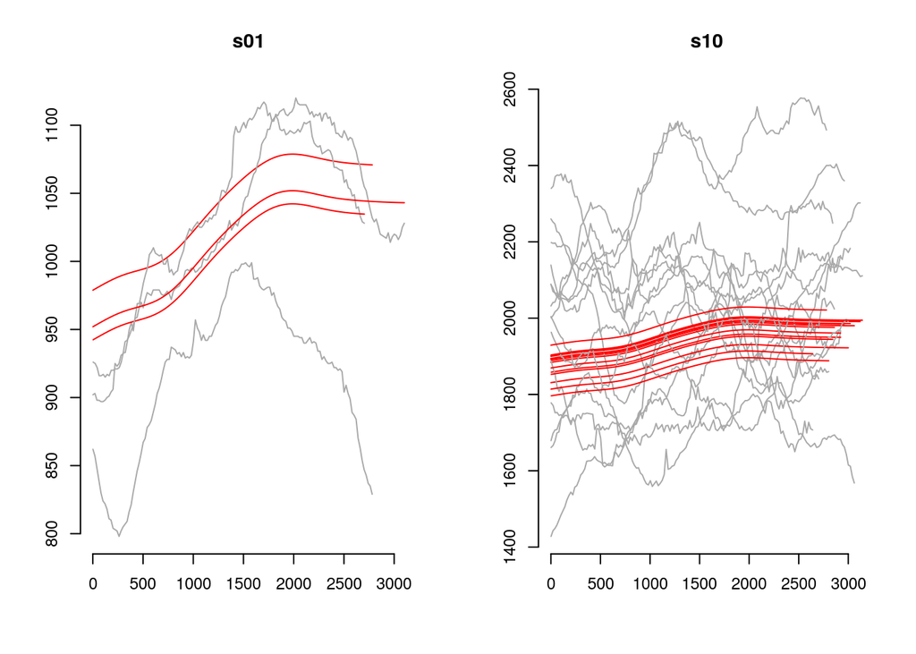

```r
# This is a simple function for comparing the
# fitted effect with the data:
plot.fitted <- function(model, subject, n=3, column="Pupil"){
  dat$fit <- fitted(model)

  # extract the items for this subject:
  items <- unique( as.character(dat[dat$Subject==subject, "Item"] ))
  # if n > length of items, then take length of items:
  n <-  min(n, length(items))
  # select n random items
  items <- sample(items,n)
  # select these items from the data:
  tmp <- droplevels( dat[dat$Subject==subject & dat$Item %in% items,
                         c("Time", "Item", column, "fit")])
  # set up empty plot window
  emptyPlot(range(tmp$Time), range(tmp[,column]), main=subject)
  # plot the items and their fitted effects:
  for(i in items){
    lines(tmp[tmp$Item==i,]$Time, tmp[tmp$Item==i,column], col='darkgray', xpd=TRUE)
    lines(tmp[tmp$Item==i,]$Time, tmp[tmp$Item==i,]$fit, col='red', xpd=TRUE)
  }
}
## end of function

par(mfrow=c(1,2), cex = 0.75)
plot.fitted(m2, 's01')

plot.fitted(m2, 's10', n=15)
```

**Why does the fitted effect pattern look different in each new plot?**

The plots change when the code is run again because the function chooses *n* events at random.

**What model terms are the same for all subjects and what is different?**

Same for all subjects: intercept, `Time` smooth, random intercept for `Item`. Different between subjects: random intercept for `Subject`.

### c. Random smooths

Instead of random intercepts for `Subject` and `Item`, fit a random factor smooth over time for each:

```r
m3 <- bam(Pupil ~ s(Time) + s(Time, Subject, bs = "fs") + s(Time, Item, bs = "fs"), data = dat, method = "fREML", discrete = TRUE, nthreads = 8)
```

```
## Warning in bgam.fitd(G, mf, gp, scale, nobs.extra = 0, rho = rho, coef =
## coef, : algorithm did not converge
```

```r
summary(m3)
```

```
##
## Family: gaussian
## Link function: identity
##
## Formula:
## Pupil ~ s(Time) + s(Time, Subject, bs = "fs") + s(Time, Item,
##     bs = "fs")
##
## Parametric coefficients:
##             Estimate Std. Error t value Pr(>|t|)
## (Intercept)   1092.4      131.3   8.317   <2e-16 ***
## ---
## Signif. codes:  0 '***' 0.001 '**' 0.01 '*' 0.05 '.' 0.1 ' ' 1
##
## Approximate significance of smooth terms:
##                    edf  Ref.df       F p-value
## s(Time)           4.43   4.913    1.65   0.197
## s(Time,Subject)  68.19  99.000 5608.30  <2e-16 ***
## s(Time,Item)    154.41 318.000   27.59  <2e-16 ***
## ---
## Signif. codes:  0 '***' 0.001 '**' 0.01 '*' 0.05 '.' 0.1 ' ' 1
##
## R-sq.(adj) =  0.928   Deviance explained = 92.9%
## fREML = 2.7057e+05  Scale est. = 12260     n = 44093
```

**What can we conclude about the wigglyness of the smooth for Time? Is it still significant?**

(Ignoring the warning that the algorithm did not converge.) The `Time` smooth uses 4.43 effective degrees of freedom, which would make it a nonlinear curve. That said, the corresponding p-value is not significant, which means that the smooth is not significantly different from a horizontal line at y = 0. This is not so surprising: by including a random `Time` smooth for each item and each subject, the model can already account for temporal fluctuations in pupil dilation at a much finer level.

**Why do the random smooth terms have such high `edf` value?**

The random smooth terms are fitting an independent nonlinear curve to the time series of each item/subject. This means, for example, that the model may use up to 10 base functions to capture the temporal pattern for a single participant. In the worst case, this would require 99 degrees of freedom to model the `Time` smooth for 10 participants. The same applies to the item smooths.

Visualise the smooth:

```
## Summary:
##  * Time : numeric predictor; with 30 values ranging from 0.000000 to 3243.000000.
##  * Subject : factor; set to the value(s): s01, s02, s03, s04, s05, s06, s07, s08, s09, s10.
##  * Item : factor; set to the value(s): 30.
```

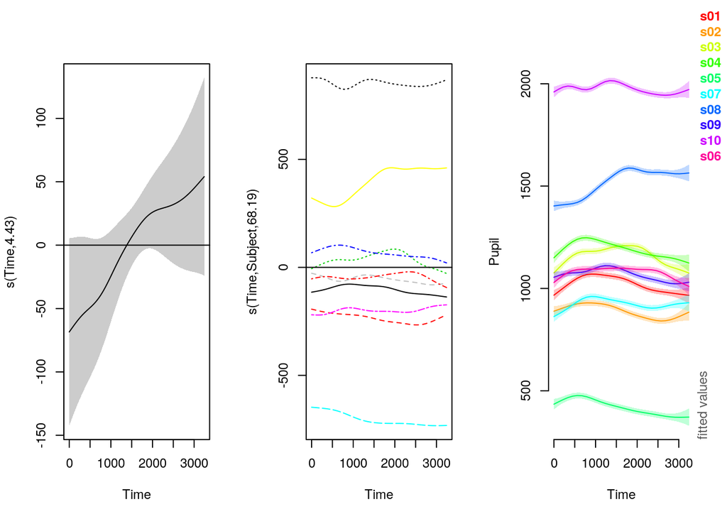

```r
par(mfrow=c(1,3), cex=0.75)

# Model term 1
plot(m3, select=1, shade=TRUE, scale=0)
abline(h=0)

# Model term 2
plot(m3, select=2)
abline(h=0)

# Summed effect of time:
plot_smooth(m3, view="Time", plot_all="Subject", rug=FALSE)
```

**What do the different plots represent?**

The plot on the left shows the partial effect of the (fixed) `Time` smooth. This plot also illustrates why the effect is not significant: the confidence interval includes the x-axis. The middle plot shows the partial effect of the random `Time` smooth of each of the 10 participants. The plot on the right shows summed effects: it adds the fixed effects of the intercept and the general `Time` smooth to the subject-specific `Time` smooths. The random `Time` smooth for item 30 is also included in these fitted values.

**How do the random smooths change the effect of pupil dilation over time?**

The general trend over time seems to be that pupil dilation increases (captured by the fixed `Time` smooth, although it is not significant in this particular model). The random smooths model residual changes in pupil dilation over time in a slightly different, nonlinear way for each participant and each item. Some show an increasing pattern, meaning that the pupil size increases even more than average in these cases; others show a decreasing pattern, in which case pupil dilation is not as strong; yet others stay fairly horizontal, indicating that the change in pupil dilation over time is already captured quite well by the fixed effect of `Time`.

**Why did we not include a random intercept for subjects together with the random smooth for subjects?**

The random smooths can already capture an offset (as is clearly demonstrated in the middle plot), so an intercept has no additional value.

Plot fitted effects (shows that variation within subjects is not captured well):

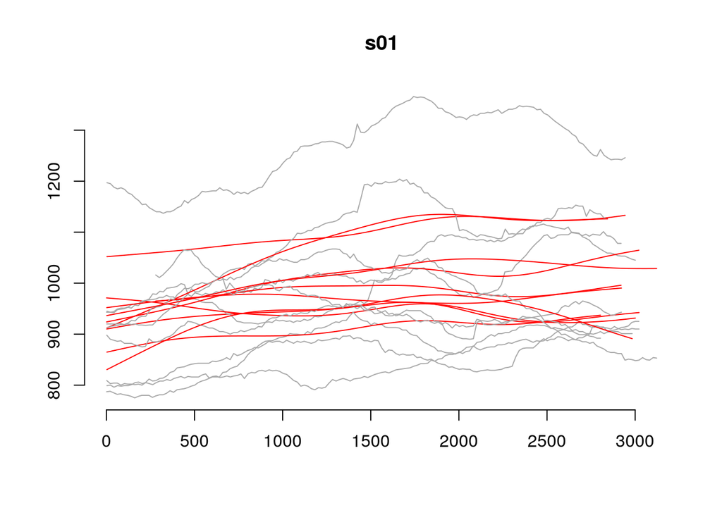

```r
plot.fitted(m3, 's01', n=10)
```

Include a random *intercept* for `Event`:

```r
m4 <- bam( Pupil ~ s(Time)
           + s(Time, Subject, bs='fs', m=1)
           + s(Time, Item, bs='fs', m=1)
           + s(Event, bs='re') , data=dat, discrete=TRUE, nthreads = 8)
summary(m4)
```

```
##
## Family: gaussian
## Link function: identity
##
## Formula:
## Pupil ~ s(Time) + s(Time, Subject, bs = "fs", m = 1) + s(Time,
##     Item, bs = "fs", m = 1) + s(Event, bs = "re")
##
## Parametric coefficients:
##             Estimate Std. Error t value Pr(>|t|)
## (Intercept)   1083.3      127.5   8.496   <2e-16 ***
## ---
## Signif. codes:  0 '***' 0.001 '**' 0.01 '*' 0.05 '.' 0.1 ' ' 1
##
## Approximate significance of smooth terms:
##                    edf  Ref.df         F  p-value
## s(Time)           6.91   7.192 3.834e+00 0.000376 ***
## s(Time,Subject)  79.07  89.000 4.931e+06  < 2e-16 ***
## s(Time,Item)    219.94 287.000 8.101e+03 5.66e-16 ***
## s(Event)        286.31 308.000 2.875e+02  < 2e-16 ***
## ---
## Signif. codes:  0 '***' 0.001 '**' 0.01 '*' 0.05 '.' 0.1 ' ' 1
##
## R-sq.(adj) =  0.976   Deviance explained = 97.7%
## fREML = 2.4709e+05  Scale est. = 4051.5    n = 44093
```

Visualise the smooth terms in the model with random `Event` intercepts:

```
## Summary:
##  * Time : numeric predictor; with 30 values ranging from 0.000000 to 3243.000000.
##  * Subject : factor; set to the value(s): s08. (Might be canceled as random effect, check below.)
##  * Item : factor; set to the value(s): 30. (Might be canceled as random effect, check below.)
##  * Event : factor; set to the value(s): s01.5. (Might be canceled as random effect, check below.)
##  * NOTE : The following random effects columns are canceled: s(Time,Subject),s(Time,Item),s(Event)
##
```

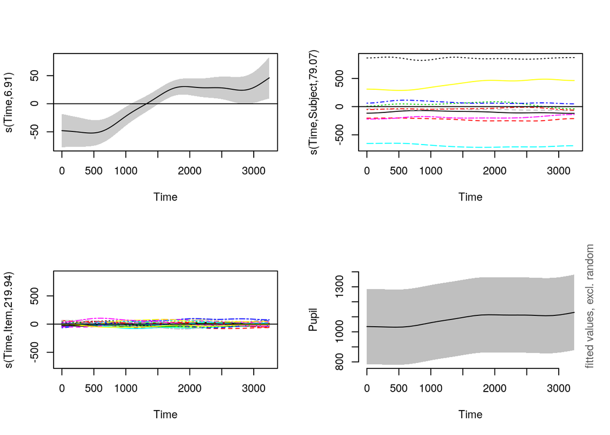

```r
par(mfrow=c(2,2), cex=0.75)

# Model term 1
plot(m4, select=1, shade=TRUE, scale=0)
abline(h=0)

# Model term 2
plot(m4, select=2)
abline(h=0)

# Model term 3
plot(m4, select=3)
abline(h=0)

# Model term 4
plot_smooth(m4, view="Time", rm.ranef=TRUE)
```

Visualise the fitted effects:

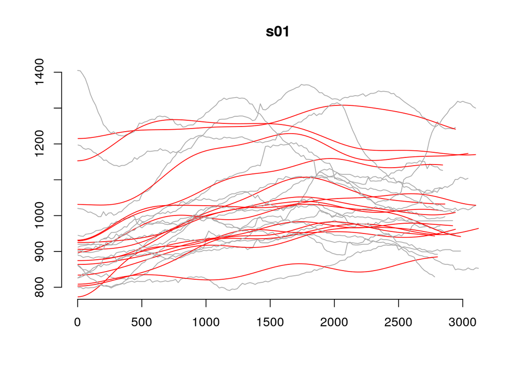

```r
plot.fitted(m4, 's01', n=15)
```

**Why is it useful to add intercepts for each `Event` rather than for each `Item`? Why would the random effects of `Subject` and `Item` in many time series data not be sufficient?**

It is clear from the fitted effects plot above that there are sizeable baseline differences in pupil size *within* participants, which is to be expected as pupil size can fluctuate naturally over a task. A random `Subject` effect cannot capture this as it is the same for all the subject's trials. Furthermore, in many cases the difference in baseline pupil size is already present at *t = 0*, meaning that it has little to do with the item itself, and that a random `Item` effect is therefore ineffective at capturing this variance. The `Event` intercept can account for these general fluctuations in pupil size that are not consistently tied to a subject or item much better since the intercept is fitted to each trial individually.

**What is your opinion on the model fit? What random effect would improve the model further?**

Based on the plots above, this model appears to fit the data quite well. It could be further improved with a random factor smooth for each `Event` over `Time` (instead of the random intercept for `Event`). This would allow it to fit differences in the magnitude of the pupil dilation better (with a random intercept the model still assumes that the change in pupil size is the same regardless of how big the pupil is at the start of the trial, which does not seem like a reasonable assumption).

### d. Model criticisn

Inspect the residuals of `m4`:

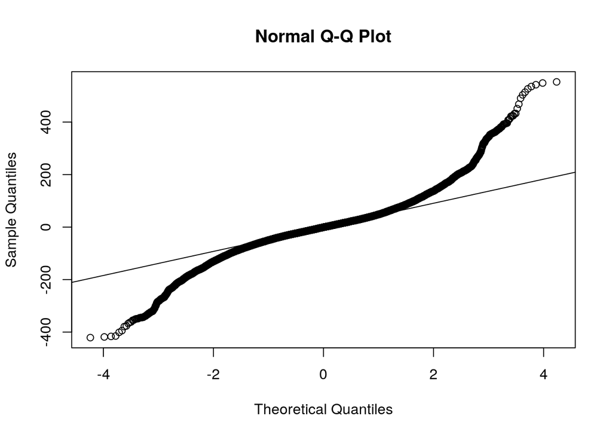

```r
qqnorm(resid(m4))
qqline(resid(m4))
```

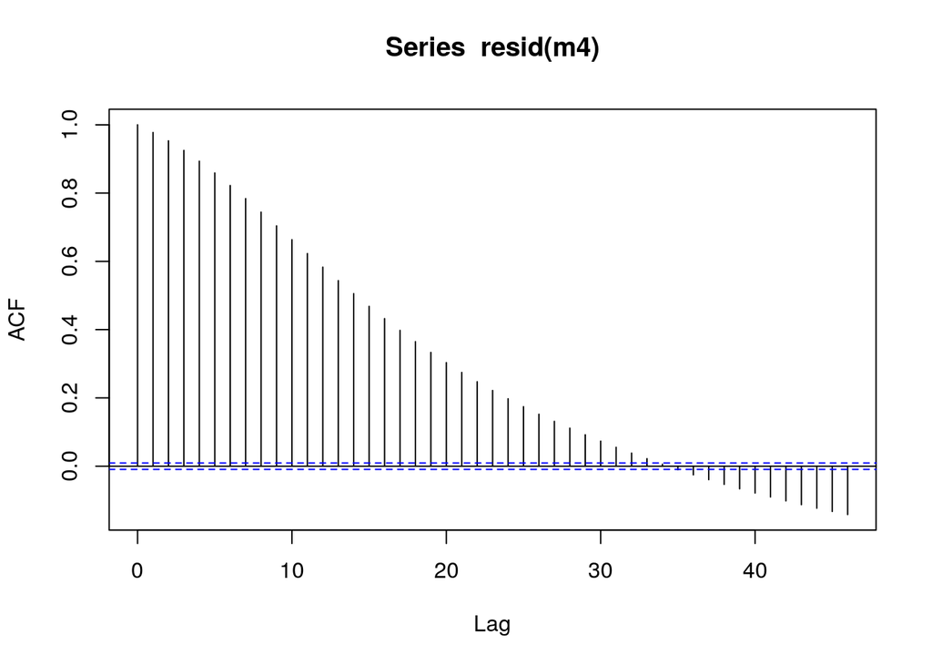

```r
acf(resid(m4))
```

**Shortly describe the QQ plot: what do the axis represent, and how could a QQ plot be interpreted.**

The QQ-plot checks whether the residuals follow a normal distribution (the assumption of normality). The x-axis shows where each residual would fall in a normal distribution, expressed in theoretical quantiles; the y-axis shows to which quantile the residual belongs in the actual distribution. The assumed normal distribution is indicated with the diagonal line. This means that residuals that conform to the normality assumption would appear as points on or close to the diagonal. If the points systematically deviate from the diagonal (as they do here), the normality assumption is violated.

**Describe the pattern in the QQ plot. What do you conclude with respect to the distribution of the residuals? Is this pattern good or bad?**

The QQ-plot shows that the residuals are not normally distributed, which is bad. Values on the left are more extreme than they should be according to the normality assumption, which means that the left tail of the distribution is relatively heavy. The same pattern is visible on the right side: there is a heavier right tail than would be expected from a normal distribution.

**Shortly describe the ACF: what do the axis represent, and how could an ACF plot be interpreted.**

The ACF plot shows the degree of autocorrelation in the residuals. The height of each line represents the correlation between the residuals and the lagged residuals (residuals shifted by a lag of 1, 2, 3, etc.; shown on the x-axis). We assume the residuals to be independent from one another, in which case the ACF plot would show autocorrelations close to zero. However, if there are regularities in the signal that the model has not explained, the will show up in the residuals, and the autocorrelation will be much higher. Such cases mean the data should be adjusted (more time between samples), the model should be changd to include terms that can explain regularities (e.g. random effects for subjects), or an AR1 model should be included.

**Describe the pattern in the ACF plot. What do you conclude with respect to the independence of the residuals? Is there structure in the residuals?**

In this case, the degree of autocorrelation is extremely high at lag 1 and quite persistent over greater lags. The value of one residual is almost perfectly correlated with the value of the next residual, and still strongly correlated with residuals that are further away. This means that there are strong regularities in the signal that the model has not accounted for, which is not good.

Include an AR1 model. Start by adding a `start.event` column:

```r
dat <- start_event(dat, event="Event")
```

**Inspect the new column. What does the column indicate? Why does the AR1 model need this information?**

This column marks the first observation in each `Event` (trial). The AR1 model needs this to delineate events: while it should expect residuals from observations within the same trial to be correlated, it should not assume that the residual of the last observation in a trial is necessarily correlated with that of the first observation in another trial.

Set `rho` to the autocorrelation at lag 1:

```r
rho <- start_value_rho(m4)
```

Rerun the model with the included AR1 model:

```r
m4b <- bam( Pupil ~ s(Time)
          + s(Time, Subject, bs='fs', m=1)
          + s(Time, Item, bs='fs', m=1)
          + s(Event, bs='re')
          , data=dat, AR.start=dat$start.event, rho=rho, discrete=TRUE, nthreads = 8)
summary(m4b)
```

```
##
## Family: gaussian
## Link function: identity
##
## Formula:
## Pupil ~ s(Time) + s(Time, Subject, bs = "fs", m = 1) + s(Time,
##     Item, bs = "fs", m = 1) + s(Event, bs = "re")
##
## Parametric coefficients:
##             Estimate Std. Error t value Pr(>|t|)
## (Intercept)   1081.3      127.6   8.472   <2e-16 ***
## ---
## Signif. codes:  0 '***' 0.001 '**' 0.01 '*' 0.05 '.' 0.1 ' ' 1
##
## Approximate significance of smooth terms:
##                    edf  Ref.df        F  p-value
## s(Time)           8.26   8.365    23.55  < 2e-16 ***
## s(Time,Subject)  79.83  89.000 18657.93  < 2e-16 ***
## s(Time,Item)    241.08 287.000    35.15 2.61e-10 ***
## s(Event)        267.91 308.000    15.35  < 2e-16 ***
## ---
## Signif. codes:  0 '***' 0.001 '**' 0.01 '*' 0.05 '.' 0.1 ' ' 1
##
## R-sq.(adj) =  0.972   Deviance explained = 97.2%
## fREML = 1.5458e+05  Scale est. = 1364.4    n = 44093
```

**Inspect the summary and the plots to see what has changed in the model.**

The summary looks about the same as that of the model without AR1: all predictors are still significant and the amount of variance explained is very similar. The smooth terms (see below) also look similar to before. The distribution of the residuals (see below) is still wider than a normal distribution, but the autocorrelation in the residuals has been reduced.

```
## Summary:
##  * Time : numeric predictor; with 30 values ranging from 0.000000 to 3243.000000.
##  * Subject : factor; set to the value(s): s08. (Might be canceled as random effect, check below.)
##  * Item : factor; set to the value(s): 30. (Might be canceled as random effect, check below.)
##  * Event : factor; set to the value(s): s01.5. (Might be canceled as random effect, check below.)
##  * NOTE : The following random effects columns are canceled: s(Time,Subject),s(Time,Item),s(Event)
##
```

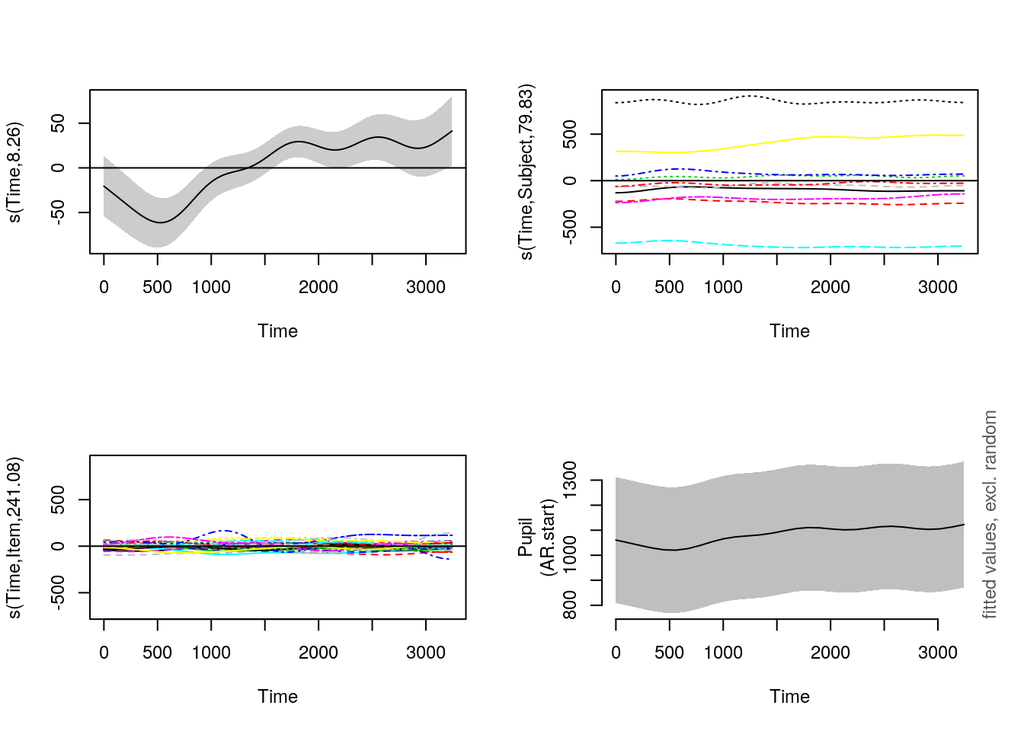

```r
par(mfrow=c(2,2), cex=0.75)

# Model term 1
plot(m4b, select=1, shade=TRUE, scale=0)
abline(h=0)

# Model term 2
plot(m4b, select=2)
abline(h=0)

# Model term 3
plot(m4b, select=3)
abline(h=0)

# Model term 4
plot_smooth(m4b, view="Time", rm.ranef=TRUE)
```

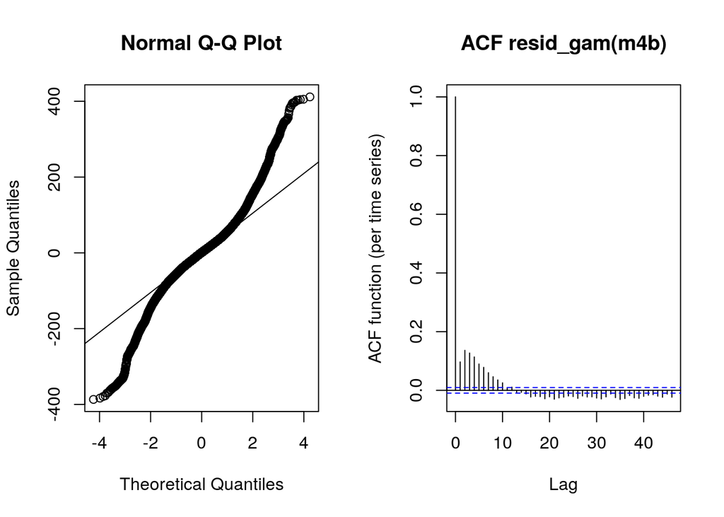

```r
par(mfrow = c(1,2))
qqnorm(resid(m4b))
qqline(resid(m4b))
acf_resid(m4b)
```

Two plots of the new residuals:

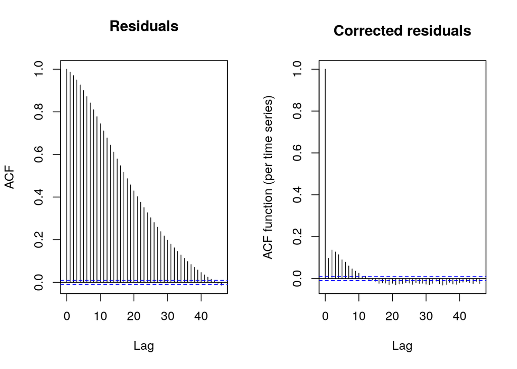

```r
par(mfrow=c(1,2))

acf(resid(m4b), main='Residuals')
acf_resid(m4b, main='Corrected residuals')
```

**What do these plots represent? Did the AR1 model reduce the autocorrelation?**

The plot on the left is the same autocorrelation plot as before. The plot on the right shows the autocorrelation in the residuals after they have been corrected by the AR1 model. It is clear that the AR1 model did indeed reduce the autocorrelation.

**Use the function compareML to compare the two models, m4 and m4b. Which one is preferred?**

Based on its much lower AIC score (see below), the model that includes the AR1 model is preferred.

```r
compareML(m4, m4b)
```

```
## m4: Pupil ~ s(Time) + s(Time, Subject, bs = "fs", m = 1) + s(Time,
##     Item, bs = "fs", m = 1) + s(Event, bs = "re")
##
## m4b: Pupil ~ s(Time) + s(Time, Subject, bs = "fs", m = 1) + s(Time,
##     Item, bs = "fs", m = 1) + s(Event, bs = "re")
##
## Model m4b preferred: lower fREML score (92517.077), and equal df (0.000).
## -----
##   Model    Score Edf Difference    Df
## 1    m4 247094.8   8
## 2   m4b 154577.7   8 -92517.077 0.000
##
## AIC difference: 184163.87, model m4b has lower AIC.
```

Compare the ACF lag 1 value for different events:

```r
acf_resid(m4b, split_pred=list(Event=dat$Event), n=9)
```

```
## Quantiles to be plotted:
##          0%       12.5%         25%       37.5%         50%       62.5%
## -0.30922702 -0.02026280  0.02195736  0.05785908  0.09748518  0.16003111
##         75%       87.5%        100%
##  0.23230434  0.32539339  0.80109059
```

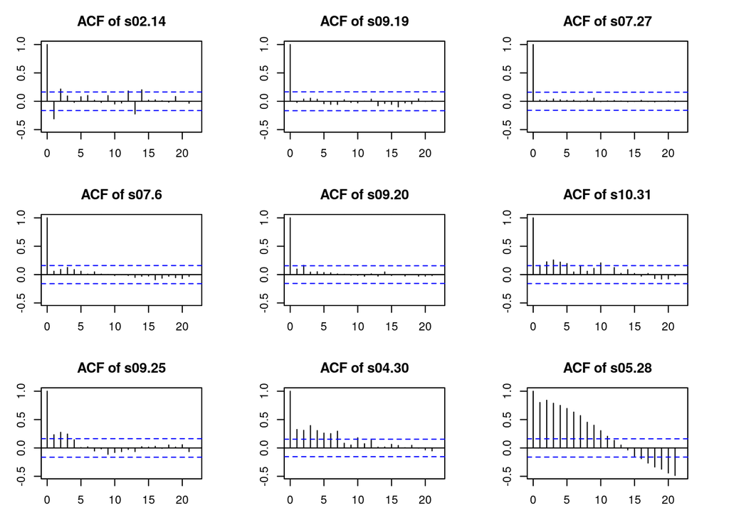

**The current implementation of AR1 model may be too simple to account for all autocorrelation problems in the data. Given the 9 plots, what would be a useful extansion / adjustment of the AR1 model?**

Judging by the plots, it appears that for most of the distribution, autocorrelation is sufficiently accounted for by the current AR1 model. Perhaps including a higher-order AR(*ρ*) model would reduce the unexplained autocorrelation in the most extreme cases. Alternatively, it might help to increase the interval between consecutive observations, since observations that are further apart are naturally less correlated.

### e. Investigating the effects of image type and introduction order

Test whether `imageType` and `introOrder` have an effect on the pupil dilation trajectory. Since these two variables are categorical, we can make a `condition` variable for the interaction of the two, so that we end up with four conditions:

```r
dat$condition <- interaction(dat$imageType, dat$introOrder)
```

Include the interaction between `Time` and `condition` in the previous model by fitting the `Time` smooth separately for each condition. I include a main effect of condition, so that the smooth does not have to fit the entire baseline difference between conditions:

```r
m5 <- bam(Pupil ~ condition +
            s(Time, by = condition) +
            s(Time, Subject, bs = "fs", m = 1) +
            s(Time, Item, bs = "fs", m = 1) +
            s(Event, bs = "re"),
          data = dat,
          AR.start = dat$start.event,
          rho = rho,
          discrete = TRUE,
          nthreads = 8)
summary(m5)
```

```
##
## Family: gaussian
## Link function: identity
##
## Formula:
## Pupil ~ condition + s(Time, by = condition) + s(Time, Subject,
##     bs = "fs", m = 1) + s(Time, Item, bs = "fs", m = 1) + s(Event,
##     bs = "re")
##
## Parametric coefficients:
##                            Estimate Std. Error t value Pr(>|t|)
## (Intercept)                 1093.43     127.88   8.551   <2e-16 ***
## conditionself-oriented.A1    -30.76      16.34  -1.883   0.0598 .
## conditionother-oriented.A2   -21.79      15.86  -1.374   0.1695
## conditionself-oriented.A2    -17.78      16.19  -1.099   0.2720
## ---
## Signif. codes:  0 '***' 0.001 '**' 0.01 '*' 0.05 '.' 0.1 ' ' 1
##
## Approximate significance of smooth terms:
##                                        edf  Ref.df         F  p-value
## s(Time):conditionother-oriented.A1   8.499   8.698    13.221  < 2e-16 ***
## s(Time):conditionself-oriented.A1    8.696   8.820    25.235  < 2e-16 ***
## s(Time):conditionother-oriented.A2   7.768   8.129     9.289 2.93e-10 ***
## s(Time):conditionself-oriented.A2    7.332   7.772     9.922 4.82e-08 ***
## s(Time,Subject)                     80.738  89.000 18739.677  < 2e-16 ***
## s(Time,Item)                       240.466 287.000    33.963 1.18e-09 ***
## s(Event)                           265.166 308.000    15.275  < 2e-16 ***
## ---
## Signif. codes:  0 '***' 0.001 '**' 0.01 '*' 0.05 '.' 0.1 ' ' 1
##
## R-sq.(adj) =  0.972   Deviance explained = 97.2%
## fREML = 1.5448e+05  Scale est. = 1357.6    n = 44093
```

**Inspect the summary. What can we conclude about the differences between the four experimental conditions?**

Based on the summary alone it is hard to conclude much about the differences between conditions; none of the intercept differences between conditions is significant, and we know that the `Time` smooth is significantly different from a horizontal line at *y = 0* in all four conditions, but not how it differs *between* conditions. We can plot the fitted effects for all conditions (see below), but as expected based on the summary they look very similar.

```
## Summary:
##  * condition : factor; set to the value(s): other-oriented.A1, other-oriented.A2, self-oriented.A1, self-oriented.A2.
##  * Time : numeric predictor; with 30 values ranging from 0.000000 to 3243.000000.
##  * Subject : factor; set to the value(s): s08. (Might be canceled as random effect, check below.)
##  * Item : factor; set to the value(s): 30. (Might be canceled as random effect, check below.)
##  * Event : factor; set to the value(s): s01.5. (Might be canceled as random effect, check below.)
##  * NOTE : The following random effects columns are canceled: s(Time,Subject),s(Time,Item),s(Event)
##
```

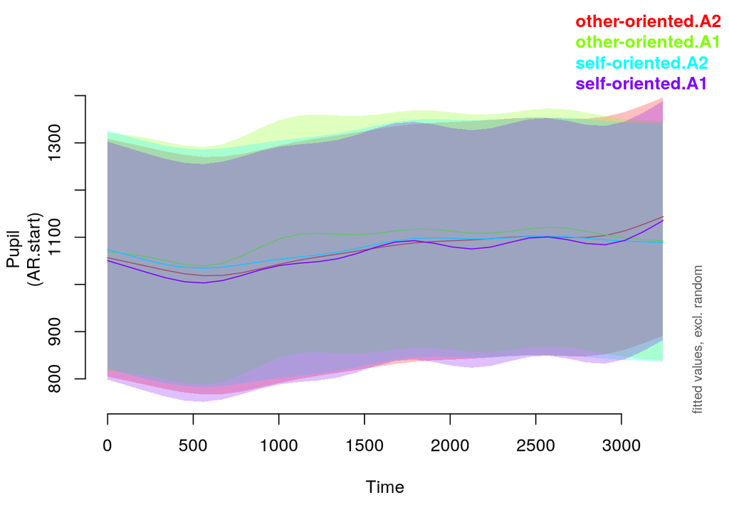

```r
plot_smooth(m5, view = "Time", plot_all = "condition", rm.ranef = TRUE)
```

**Name two other methods that we could use to investigate whether there are significant differences in the pupil size trajectories of the experimental conditions.**

The `plot_diff()` function can show pairwise comparisons between conditions, and will highlight in red where there are significant differences (see the comparison plots below). Another way to test for differences between conditions would be to use contrast coding in the model, where one condition is set to be the reference level and significant effects for other conditions indicate that they are different from the reference condition.

```r
par(mfrow = c(3,2), cex = 0.75)
plot_diff(m5, view = "Time", comp = list(condition = c("other-oriented.A1", "self-oriented.A1")), rm.ranef = TRUE)
```

```
## Summary:
##  * Time : numeric predictor; with 100 values ranging from 0.000000 to 3243.000000.
##  * Subject : factor; set to the value(s): s08. (Might be canceled as random effect, check below.)
##  * Item : factor; set to the value(s): 30. (Might be canceled as random effect, check below.)
##  * Event : factor; set to the value(s): s01.5. (Might be canceled as random effect, check below.)
##  * NOTE : The following random effects columns are canceled: s(Time,Subject),s(Time,Item),s(Event)
##
```

```
##
## Time window(s) of significant difference(s):
##  229.303030 - 1506.848485
##  2030.969697 - 2129.242424
```

```r
plot_diff(m5, view = "Time", comp = list(condition = c("other-oriented.A1", "other-oriented.A2")), rm.ranef = TRUE)
```

```
## Summary:
##  * Time : numeric predictor; with 100 values ranging from 0.000000 to 3243.000000.
##  * Subject : factor; set to the value(s): s08. (Might be canceled as random effect, check below.)
##  * Item : factor; set to the value(s): 30. (Might be canceled as random effect, check below.)
##  * Event : factor; set to the value(s): s01.5. (Might be canceled as random effect, check below.)
##  * NOTE : The following random effects columns are canceled: s(Time,Subject),s(Time,Item),s(Event)
##
```

```
##
## Time window(s) of significant difference(s):
##  753.424242 - 1506.848485
##  3177.484848 - 3243.000000
```

```r
plot_diff(m5, view = "Time", comp = list(condition = c("other-oriented.A1", "self-oriented.A2")), rm.ranef = TRUE)
```

```
## Summary:
##  * Time : numeric predictor; with 100 values ranging from 0.000000 to 3243.000000.
##  * Subject : factor; set to the value(s): s08. (Might be canceled as random effect, check below.)
##  * Item : factor; set to the value(s): 30. (Might be canceled as random effect, check below.)
##  * Event : factor; set to the value(s): s01.5. (Might be canceled as random effect, check below.)
##  * NOTE : The following random effects columns are canceled: s(Time,Subject),s(Time,Item),s(Event)
##
```

```
##
## Time window(s) of significant difference(s):
##  917.212121 - 1375.818182
```

```r
plot_diff(m5, view = "Time", comp = list(condition = c("self-oriented.A1", "other-oriented.A2")), rm.ranef = TRUE)
```

```
## Summary:
##  * Time : numeric predictor; with 100 values ranging from 0.000000 to 3243.000000.
##  * Subject : factor; set to the value(s): s08. (Might be canceled as random effect, check below.)
##  * Item : factor; set to the value(s): 30. (Might be canceled as random effect, check below.)
##  * Event : factor; set to the value(s): s01.5. (Might be canceled as random effect, check below.)
##  * NOTE : The following random effects columns are canceled: s(Time,Subject),s(Time,Item),s(Event)
##
```

```
##
## Difference is not significant.
```

```r
plot_diff(m5, view = "Time", comp = list(condition = c("self-oriented.A1", "self-oriented.A2")), rm.ranef = TRUE)
```

```
## Summary:
##  * Time : numeric predictor; with 100 values ranging from 0.000000 to 3243.000000.
##  * Subject : factor; set to the value(s): s08. (Might be canceled as random effect, check below.)
##  * Item : factor; set to the value(s): 30. (Might be canceled as random effect, check below.)
##  * Event : factor; set to the value(s): s01.5. (Might be canceled as random effect, check below.)
##  * NOTE : The following random effects columns are canceled: s(Time,Subject),s(Time,Item),s(Event)
##
```

```
##
## Time window(s) of significant difference(s):
##  3243.000000 - 3243.000000
##  3243.000000 - NA
```

```
## Summary:
##  * Time : numeric predictor; with 100 values ranging from 0.000000 to 3243.000000.
##  * Subject : factor; set to the value(s): s08. (Might be canceled as random effect, check below.)
##  * Item : factor; set to the value(s): 30. (Might be canceled as random effect, check below.)
##  * Event : factor; set to the value(s): s01.5. (Might be canceled as random effect, check below.)
##  * NOTE : The following random effects columns are canceled: s(Time,Subject),s(Time,Item),s(Event)
##
```

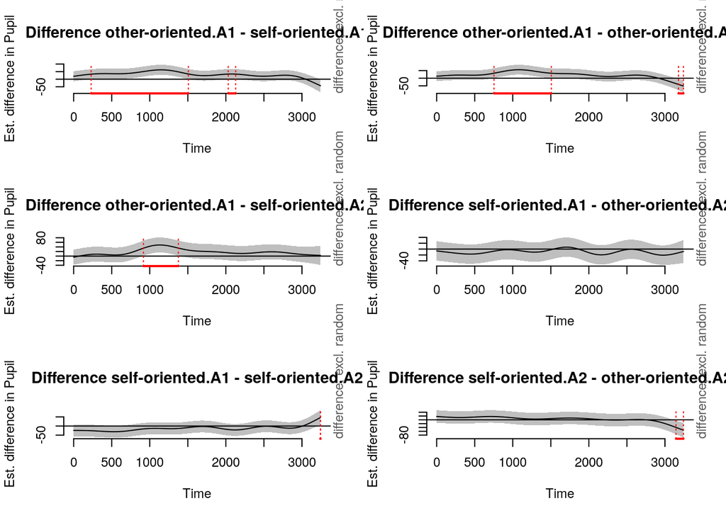

```
##
## Time window(s) of significant difference(s):
##  3144.727273 - 3243.000000
```

```r
plot_diff(m5, view = "Time", comp = list(condition = c("self-oriented.A2", "other-oriented.A2")), rm.ranef = TRUE)
```

Represent the conditions using *binary predictors* (dummy coding):

```r
dat$IsA1 <- ifelse(dat$introOrder=="A1", 1, 0)
dat$IsSelf <- ifelse(dat$imageType=="self-oriented", 1, 0)
dat$IsA1Self <- ifelse(dat$introOrder=="A1" & dat$imageType=="self-oriented", 1, 0)

m6 <- bam( Pupil ~ s(Time)
          + s(Time, by=IsA1)
          + s(Time, by=IsSelf)
          + s(Time, by=IsA1Self)
          + s(Time, Subject, bs = 'fs', m = 1)
          + s(Time, Item, bs = 'fs', m = 1)
          + s(Event, bs = 're'),
          data = dat,
          AR.start = dat$start.event,
          rho = rho,
          discrete=TRUE,
          nthreads = 8)
summary(m6)
```

```
##
## Family: gaussian
## Link function: identity
##
## Formula:
## Pupil ~ s(Time) + s(Time, by = IsA1) + s(Time, by = IsSelf) +
##     s(Time, by = IsA1Self) + s(Time, Subject, bs = "fs", m = 1) +
##     s(Time, Item, bs = "fs", m = 1) + s(Event, bs = "re")
##
## Parametric coefficients:
##             Estimate Std. Error t value Pr(>|t|)
## (Intercept)   1076.1      127.9   8.413   <2e-16 ***
## ---
## Signif. codes:  0 '***' 0.001 '**' 0.01 '*' 0.05 '.' 0.1 ' ' 1
##
## Approximate significance of smooth terms:
##                      edf  Ref.df         F  p-value
## s(Time)            7.612   7.846     9.930 5.35e-09 ***
## s(Time):IsA1       9.427   9.866    11.561  < 2e-16 ***
## s(Time):IsSelf     7.966   9.112     3.415 0.000314 ***
## s(Time):IsA1Self   9.328   9.801     8.157 1.35e-10 ***
## s(Time,Subject)   80.100  89.000 18744.105  < 2e-16 ***
## s(Time,Item)     240.142 287.000    33.941 8.08e-10 ***
## s(Event)         265.254 305.000    15.426  < 2e-16 ***
## ---
## Signif. codes:  0 '***' 0.001 '**' 0.01 '*' 0.05 '.' 0.1 ' ' 1
##
## R-sq.(adj) =  0.972   Deviance explained = 97.2%
## fREML = 1.5448e+05  Scale est. = 1357.4    n = 44093
```

**Inspect the summary. What is represented by the intercept?**

The intercept represents the condition in which each of the binary predictors is zero: *other-oriented:A2*.

**Describe what the four fixed effects trajectories that include Time represent (i.e., the top four lines of the smooth term summary).**

They describe the `Time` smooth belonging to each of the four conditions. From top to bottom: *other-oriented:A2*, *other-oriented:A1*, *self-oriented:A2*, and *self-oriented:A1*.

**Why do we not need to include the binary predictors as parametric terms / main effects ( intercept adjustments)?**

It would not make sense to include tem as main effects as we already fit a separate smooth term for each condition and 'turn them on or off' based on the condition (unlike in the previous model, where a single smooth term explicitly captured all differences between conditions).

**What can we conclude about the differences between the four experimental conditions?**

Based on this model summary, we can conclude that the pupil dilation trajectory is significantly different when:

- the actor is introduced first rather than second (when an other-oriented action is shown);
- a self-oriented action is shown rather than an other-oriented action (when the actor is introduced second);
- a self-oriented action is shown rather than an other-oriented action, and the actor is introduced first rather than second.

Inspect the three binary predictor curves:

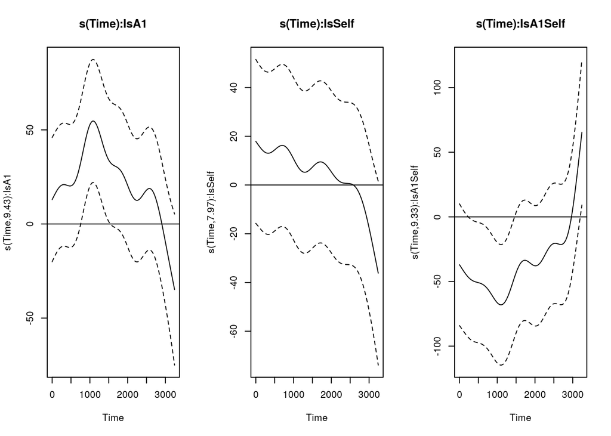

```r
par(mfrow = c(1,3))
plot(m6, scale=0, select=2, main = "s(Time):IsA1")
abline(h=0)

plot(m6, scale=0, select=3, main = "s(Time):IsSelf")
abline(h=0)

plot(m6, scale=0, select=4, main = "s(Time):IsA1Self")
abline(h=0)
```

**Inspect the plots. What can we conclude about the differences between the four experimental conditions?**

**Use model comparisons (functions `compareML` and `AIC`) to test whether the binary interaction predictor `IsSelfA1` is significantly contributing to the model. Provide the code for the model comparison in your assignment. (Note that actually model `m6` and the new model should be run with `method='ML'` included for fixed effects comparisons, but for time reasons we will ignore this for the current assignment.)**

See below.

First run `m6` again without the `IsSelfA1` predictor:

```r
m6b <- bam( Pupil ~ s(Time)
          + s(Time, by=IsA1)
          + s(Time, by=IsSelf)
          + s(Time, Subject, bs = 'fs', m = 1)
          + s(Time, Item, bs = 'fs', m = 1)
          + s(Event, bs = 're'),
          data = dat,
          AR.start = dat$start.event,
          rho = rho,
          discrete=TRUE,
          nthreads = 8)
summary(m6b)
```

```
##
## Family: gaussian
## Link function: identity
##
## Formula:
## Pupil ~ s(Time) + s(Time, by = IsA1) + s(Time, by = IsSelf) +
##     s(Time, Subject, bs = "fs", m = 1) + s(Time, Item, bs = "fs",
##     m = 1) + s(Event, bs = "re")
##
## Parametric coefficients:
##             Estimate Std. Error t value Pr(>|t|)
## (Intercept)   1085.5      127.9   8.484   <2e-16 ***
## ---
## Signif. codes:  0 '***' 0.001 '**' 0.01 '*' 0.05 '.' 0.1 ' ' 1
##
## Approximate significance of smooth terms:
##                     edf  Ref.df         F  p-value
## s(Time)           7.565   7.816     8.816 1.93e-07 ***
## s(Time):IsA1      9.580   9.949    10.732  < 2e-16 ***
## s(Time):IsSelf    9.210   9.845     7.038 6.01e-11 ***
## s(Time,Subject)  80.076  89.000 18792.552  < 2e-16 ***
## s(Time,Item)    240.296 287.000    34.618 2.70e-10 ***
## s(Event)        266.329 306.000    15.464  < 2e-16 ***
## ---
## Signif. codes:  0 '***' 0.001 '**' 0.01 '*' 0.05 '.' 0.1 ' ' 1
##
## R-sq.(adj) =  0.972   Deviance explained = 97.2%
## fREML = 1.5451e+05  Scale est. = 1359.4    n = 44093
```

Compare this model to the full model:

```r
AIC(m6, m6b)
```

|  | df | AIC |
| --- | --- | --- |
| m6 | 623.8500 | 307630.0 |
| m6b | 616.2642 | 307687.3 |

```r
compareML(m6, m6b)
```

```
## m6: Pupil ~ s(Time) + s(Time, by = IsA1) + s(Time, by = IsSelf) +
##     s(Time, by = IsA1Self) + s(Time, Subject, bs = "fs", m = 1) +
##     s(Time, Item, bs = "fs", m = 1) + s(Event, bs = "re")
##
## m6b: Pupil ~ s(Time) + s(Time, by = IsA1) + s(Time, by = IsSelf) +
##     s(Time, Subject, bs = "fs", m = 1) + s(Time, Item, bs = "fs",
##     m = 1) + s(Event, bs = "re")
##
## Chi-square test of fREML scores
## -----
##   Model    Score Edf Difference    Df   p.value Sig.
## 1   m6b 154505.5  14
## 2    m6 154475.3  17     30.229 3.000 4.692e-13  ***
##
## AIC difference: -57.28, model m6 has lower AIC.
```

**What is your conclusion based on the model comparisons, the plots, and the summary statistics?**

The full model uses more degrees of freedom, but has a significantly lower AIC score than the model that leaves out the `IsSelfA1` predictor. The plots also show that this predictor is important to include in the model: while the two components `IsA1` and `IsSelf` by themselves predict an increase or no change in pupil dilation relative to the reference condition, the interaction of these components actually makes the opposite prediction: pupil dilation *decreases* relative to the reference condition when both are true. It is therefore necessary to include the interaction in the model.